# Learning About Bias? *An Experiment on Paying Attention to News in Russia*

Anton Shirikov

as6859@columbia.edu

Columbia University

Georgiy Syunyaev

g.syunyaev@vanderbilt.edu

Vanderbilt University, WZB Berlin

## The question

- Most people consume news from media outlets that are biased *(Gentzkow and Shapiro 2006, 2010)*
  - Especially in autocracies with state control of media environment
- But very often, citizens underestimate/misunderstand the extent of the bias *(Garrett and Weeks 2017; Feldman 2011)*
- Can we prompt citizens to pay attention to media coverage?
- …Does this lead to learning about media bias and switching to less biased media?

## What we know

- Classic argument about autocracies: exposure to alternative media illuminates the bias of propaganda *(Stein 2013; Garcia-Arenas 2016; Gläßel and Paula 2020)*
  - But difficult to establish causal effects
- In other contexts, exposure to out-partisan media *(Broockman and Kalla 2022; Searles et al. 2022; Chopra, Haaland, and Roth 2023)* has limited effects on media consumption or media perceptions
- Corrections, fact-checks, and news literacy interventions sometimes work *(Guess et al. 2020)* but sometimes fail or backfire *(Nyhan and Reifler 2010; Badrinathan 2021; Chopra, Haaland, and Roth 2022)*

## Our argument

- Citizens in autocracies can revise their beliefs about media bias if they pay closer attention to:
  - What pro-government media covers
  - Differences between what pro-government and independent media cover
- But they need to make conclusions on their own to:
  - Prevent relying on others’ judgment
  - Avoid attributing evidence to researchers’ (or other actors’) political agenda

## Intervention and outcomes

We ask citizens to analyze the topics and sentiment of video news headlines by state and independent media

*…to answer…*

Does paying attention to what media outlet covers and how affect:

1. Knowledge of media outlets’ reporting strategies?
2. Perceptions of media outlets’ credibility?
3. Consumption of state and independent media and awareness of pro-government and critical news?
4. Political attitudes?

## Setting

- Russia: an autocratic regime with state control of media environment
  - State media are heavily pro-government
  - But more critical media also available
  - The War in Ukraine exacerbated state media control $\Rightarrow$ Hard test of our theory

## Timeline

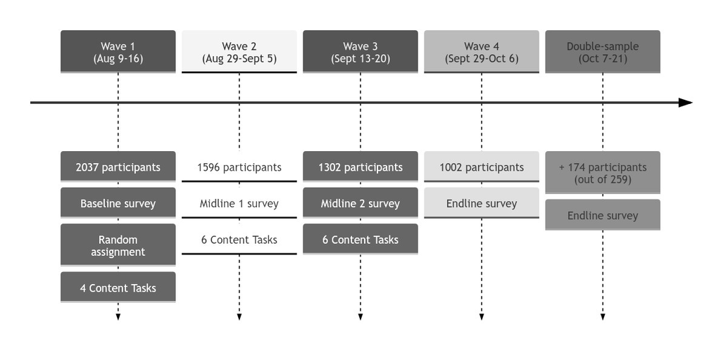

## Treatments

- Short video segments (news headlines) from three TV stations:
  - *Kultura*, a non-political TV channel that covers art, theater, architecture, etc.
  - *Rossiya-1*, one of the two main state-controlled propaganda channels
  - *RTVI*, a privately owned and editorially (semi-)independent TV station
- Each news headline segment was:
  - Brief description of main events of the day (~2 minutes)
  - Shown in the beginning of evening prime-time news broadcasts
  - Focuses on informing about main events (selection) rather than carefully framing them (slant)

## Experimental conditions

**Evaluate 4-6 video segments per wave:**

- **Placebo:** News headlines ONLY from the non-political *Kultura* TV channel
- **Pro-government:** News headlines from *Rossiya-1* AND *Kultura* TV channels
  - Order: Rossiya-1 (Date 1) $\Rightarrow$ Kultura (Date 1) $\Rightarrow$ Rossiya-1 (Date 2) $\Rightarrow$ Kultura (Date 2) …
- **Pro-government vs. Independent:** News headlines from *Rossiya-1* AND *RTVI*
  - Order: Rossiya-1 (Date 1) $\Rightarrow$ RTVI (Date 1) $\Rightarrow$ Rossiya-1 (Date 2) $\Rightarrow$ RTVI (Date 2) …

[video not shown]

## Topic count questions

- Which TV station did broadcast this video? Did the video mention [TOPIC]?
- How many times the following topics were mentioned in the video:
  - Situation in Russia in a **[negative/positive]** tone?
  - Situation in other countries in a **[negative/positive]** tone?
  - Russian federal officials in a **[negative/positive]** tone?

## Hypotheses

After treatment tasks, citizens will…

- **H1:** Learn about the types of coverage of *Rossiya-1* and *RTVI*
- **H2:** Update perceptions of media: *Rossiya-1* bias $\Uparrow$, *RTVI* bias $\Downarrow$, attributing news to *Rossiya-1* and *RTVI* $\Uparrow$
- **H3:** Adjust media consumption: *Rossiya-1* $\Downarrow$, *RTVI* $\Uparrow$, preference for *RTVI* $\Uparrow$; news awareness
- **H4:** Update political attitudes

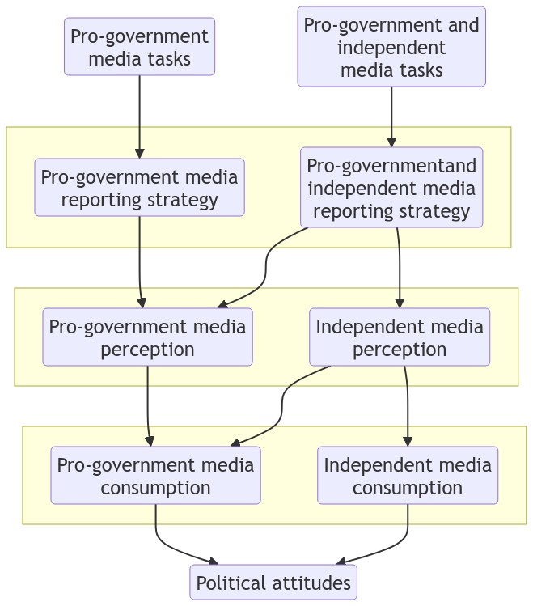

## **H1:** Learning about coverage

- Citizens recognize that Rossiya-1 covers
  - Foreign countries more and more negatively and
  - Federal authorities more and more positively

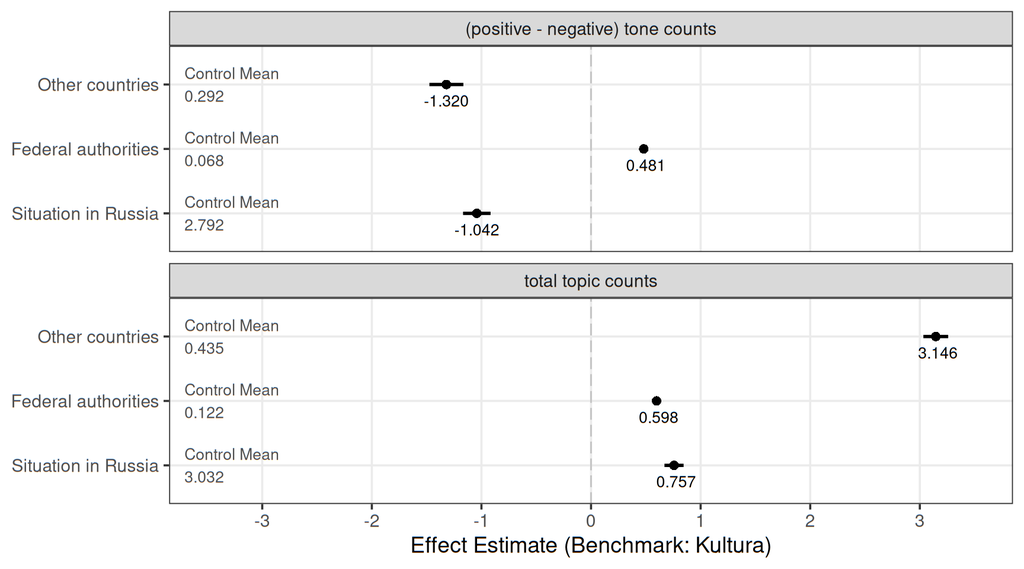

## **H1:** Learning about coverage

- Citizens recognize that RTVI covers
  - Foreign countries more and in a more positive tone and
  - Russia/federal authorities less and in a less positive tone

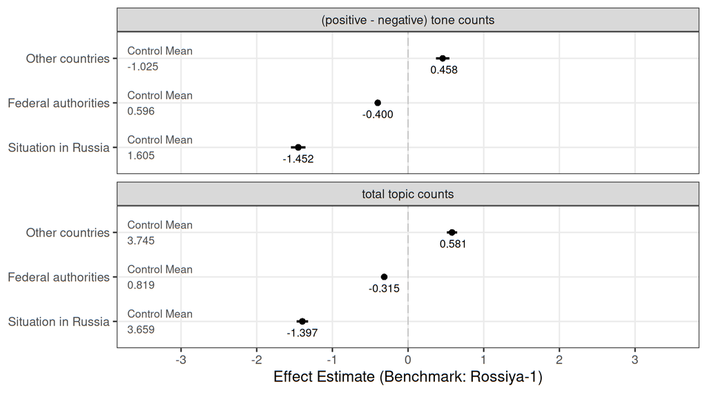

## **H2:** Perceptions of news outlets

- How likely is Rossiya-1/RTVI to cover Russia positively and foreign countries negatively?
- Drawing attention to content encourages learning about reporting strategy
- Control group means: uncertainty about RTVI coverage strategy but little uncertainty about Rossiya-1

|  | Rossiya-1 coverage: Domestic positive | Rossiya-1 coverage: Foreign negative | RTVI coverage: Domestic positive | RTVI coverage: Foreign negative | Share correctly attributed news: RTVI | Share correctly attributed news: Rossiya-1 |
| --- | --- | --- | --- | --- | --- | --- |
| Rossiya-1+Kultura | 0.023** | 0.038** | 0.039* | 0.011 | 0.038 | 0.043*** |
|  | [0.014] | [0.017] | [0.023] | [0.022] | [0.023] | [0.017] |
| Rossiya-1+RTVI | 0.019* | 0.023* | 0.066*** | 0.087*** | 0.093*** | 0.022 |
|  | [0.014] | [0.017] | [0.023] | [0.021] | [0.023] | [0.018] |
| Hypotheses | upr/upr | upr/upr | two/two | two/two | two/upr | upr/two |
| Control mean | 0.908 | 0.843 | 0.473 | 0.618 | 0.575 | 0.762 |
| Observations | 1170 | 1173 | 1171 | 1171 | 1176 | 1176 |

## **H2:** Perceptions of news outlets

- No learning about the **bias** of pro-government Rossiya-1
- But improved perceptions of independent RTVI

|  | Rossiya-1 is unbiased/independent | RTVI is unbiased/independent |
| --- | --- | --- |
| Rossiya-1+Kultura | 0.001 | -0.021 |
|  | [0.020] | [0.016] |
| Rossiya-1+RTVI | -0.007 | 0.025** |
|  | [0.020] | [0.015] |
| Hypotheses | lwr/lwr | two/upr |
| Control mean | 0.433 | 0.561 |
| Observations | 1164 | 1163 |

## **H3:** Media consumption

|  | Used last week: Rossiya-1 | Used last week: How many state outlets | Used last week: RTVI | Used last week: How many independent outlets | Behavior: Prefer Rossiya-1 over RTVI |
| --- | --- | --- | --- | --- | --- |
| Rossiya-1+Kultura | 0.065 | -0.017* | -0.018 | -0.006 | -0.044** |
|  | [0.030] | [0.013] | [0.019] | [0.011] | [0.024] |
| Rossiya-1+RTVI | 0.048 | -0.011 | 0.122*** | 0.011 | -0.097*** |
|  | [0.031] | [0.013] | [0.025] | [0.011] | [0.026] |
| Hypotheses | lwr/lwr | lwr/lwr | two/upr | two/upr | lwr/lwr |
| Control mean | 0.720 | 0.247 | 0.086 | 0.069 | 0.895 |
| Observations | 1175 | 1175 | 1175 | 1175 | 1176 |

## **H3:** News awareness

- Familiarity from last week’s headlines from state and independent media
- Increase in awareness of both pro-government and critical news

|  | Awareness of news stories Pro-government | Awareness of news stories Critical |
| --- | --- | --- |
| Rossiya-1+Kultura | 0.043** | 0.042** |
|  | [0.019] | [0.017] |
| Rossiya-1+RTVI | 0.034* | 0.026* |
|  | [0.018] | [0.017] |
| Hypotheses | two/two | two/upr |
| Control mean | 0.340 | 0.215 |
| Observations | 1175 | 1175 |

## **H4:** Political beliefs

- Three indexes: (1) approval of various Russian authorities; (2) quality of government-provided services; (3) concern about Russia’s war on Ukraine
- Lower support for the government and stronger concerns about Ukraine

|  | Authorities approval | Quality of public services | Ukraine concern |
| --- | --- | --- | --- |
| Rossiya-1+Kultura | -0.141** | -0.071 | 0.089** |
|  | [0.067] | [0.060] | [0.047] |
| Rossiya-1+RTVI | -0.101* | -0.121** | 0.058 |
|  | [0.065] | [0.060] | [0.045] |
| Hypotheses | lwr/lwr | lwr/lwr | upr/upr |
| Control mean | -0.001 | 0.001 | -0.002 |
| Observations | 1164 | 1164 | 1165 |

## Strict test of the hypotheses

- **H1:** Differences in coverage
  - **Rossiya-1 vs. Kultura:** More positive domestic coverage **/** More negative foreign coverage and positive coverage of authorities
  - **RTVI vs. Rossiya-1:** Less positive domestic coverage and coverage of authorities **/** Less negative foreign coverage
- **H2:** Effects on media perceptions
  - **Pro-government news only:** *Rossiya-1* covers domestic news positively $\Uparrow$ **/** *Rossiya-1* covers foreign news negatively $\Uparrow$
  - **Pro-government vs. Independent news:** *RTVI* covers domestic news positively $\Downarrow$ **/** *RTVI* covers foreign news negatively $\Downarrow$ **/** *RTVI* bias perceptions $\Downarrow$
  - **Both treatments:** *Rossiya-1* bias perceptions unchanged **/** Correct attribution of respective channel’s news $\Uparrow$
- **H3:** Effects on media consumption
  - **Pro-government vs. Independent news:** Self-reported *RTVI* consumption $\Uparrow$
  - **Both treatments:** Self-reported *Rossiya-1* consumption unchanged **/** Recall of pro-government news $\Uparrow$ **/** Recall of critical news $\Uparrow$ **/** Choose to watch *RTVI* $\Uparrow$
- **H4:** Effects on political attitudes
  - **Both treatments:** Approval of authorities $\Downarrow$ **/** Evaluation of government policies $\Downarrow$ **/** Concerns about the war in Ukraine $\Uparrow$

*Hypothesis **supported** or **unsupported***

## Mechanisms

- Respondents who tried RTVI were **mostly state media consumers**
- But perceptions of RTVI as unbiased and preference for RTVI only improved **among Putin critics**, not Putin supporters; existing Rossiya-1 consumers also not affected
- News awareness: pro-gov’t news $\Uparrow$ mostly **among supporters**, critical news $\Uparrow$ mostly **among critics**

**Interpretation:**: **Learning about coverage** prompts **updating about media bias or news preference** when citizens are already open to critical information; tasks increased attention to news

## Mechanisms

Effects on political beliefs:

- Approval of authorities decreased and concern about Ukraine increased **among critics and consumers of independent media**
- No effects among Putin supporters or Rossiya-1/state media consumers

**Interpretation:** Increasing attention to news can shift beliefs if news are consistent with **prior dispositions/media diets**; otherwise, little updating

## Concerns over the design?

- **No pure control?** No systematic evidence of placebo group changes over time
- **Political news push respondents away?** No differences in patterns of attrition across treatment groups
- **Less attention to political news?** High and similar rates of correct answers about the topic and channel across groups
- **Experimenter demand?** No differences across treatment groups in respondents’ assessments of study goals

## Takeaways

- Learning about the bias of propaganda is possible when citizens are more attentive
  - But it does not make them more suspicious about propaganda
- Exposure to new (critical) information sources and increased attention to media coverage can shift news interest away from propaganda and prompt belief updating
  - But mostly if citizens are at least somewhat skeptical

## Next steps

- Clarify the mechanism/causal path
- Explore heterogeneous effects further
- Trace changes in consumption/news awareness over time (not pre-registered)
- Additional outcomes (beliefs about media environment, etc.)

## References

Badrinathan, Sumitra. 2021. “Educative Interventions to Combat Misinformation: Evidence from a Field Experiment in India.” *American Political Science Review* 115 (4): 1325–41. https://doi.org/10.1017/s0003055421000459.

Broockman, David, and Joshua Kalla. 2022. “The Manifold Effects of Partisan Media on Viewers’ Beliefs and Attitudes: A Field Experiment with Fox News Viewers.” *OSF Preprints* 1.

Chopra, Felix, Ingar Haaland, and Christopher Roth. 2022. “Do People Demand Fact-Checked News? Evidence from u.s. Democrats.” *Journal of Public Economics* 205: 104549. https://doi.org/10.1016/j.jpubeco.2021.104549.

———. 2023. “The Demand for News: Accuracy Concerns Versus Belief Confirmation Motives.”

Feldman, Lauren. 2011. “Partisan Differences in Opinionated News Perceptions: A Test of the Hostile Media Effect.” *Political Behavior* 33: 407–32.

Garcia-Arenas, Javier. 2016. “The Impact of Free Media on Regime Change: Evidence from Russia.” http://www.eief.it/files/2016/01/02-jmp_garcia-arenas.pdf.

Garrett, R. Kelly, and Brian E. Weeks. 2017. “Epistemic Beliefs’ Role in Promoting Misperceptions and Conspiracist Ideation.” *PLoS ONE* 12 (9).

Gentzkow, Matthew, and Jesse M. Shapiro. 2006. “Media Bias and Reputation.” *Journal of Political Economy* 114 (2): 280–316.

———. 2010. “What Drives Media Slant? Evidence from u.s. Daily Newspapers.” *Econometrica* 78 (1): 35–71. https://doi.org/10.3982/ECTA7195.

Gläßel, Christian, and Katrin Paula. 2020. “Sometimes Less Is More: Censorship, News Falsification, and Disapproval in 1989 East Germany.” *American Journal of Political Science* 64 (3): 682–98. https://doi.org/10.1111/ajps.12501.

Guess, Andrew, Michael Lerner, Benjamin Lyons, Jacob M. Montgomery, Brendan Nyhan, Jason Reifler, and Neelanjan Sircar. 2020. “A Digital Media Literacy Intervention Increases Discernment Between Mainstream and False News in the United States and India.” *Proceedings of the National Academy of Sciences* 117 (27): 15536–45. https://doi.org/10.1073/pnas.1920498117.

Nyhan, Brendan, and Jason Reifler. 2010. “When Corrections Fail: The Persistence of Political Misperceptions.” *Political Behavior* 32 (2): 303–30.

Searles, Kathleen, Joshua P. Darr, Mingxiao Sui, Nathan Kalmoe, Raymond Pingree, and Brian Watson. 2022. “Partisan Media Effects Beyond One-Shot Experimental Designs.” *Political Science Research and Methods* 10 (1): 206–14. https://doi.org/10.1017/psrm.2021.21.

Stein, Elizabeth A. 2013. “The Unraveling of Support for Authoritarianism: The Dynamic Relationship of Media, Elites, and Public Opinion in Brazil, 1972–82.” *The International Journal of Press/Politics* 18 (1): 85–107.